# Logistic regression (RStudio Exercise 3)

Ashwini Kumar

9 February 2017

# Data

```r
library(dplyr)
alc <- read.table("http://s3.amazonaws.com/assets.datacamp.com/production/course_2218/datasets/alc.txt", sep = ",", header = TRUE)
glimpse(alc)
```

```
## Observations: 382
## Variables: 35
## $ school     <fctr> GP, GP, GP, GP, GP, GP, GP, GP, GP, GP, GP, GP, GP...
## $ sex        <fctr> F, F, F, F, F, M, M, F, M, M, F, F, M, M, M, F, F,...
## $ age        <int> 18, 17, 15, 15, 16, 16, 16, 17, 15, 15, 15, 15, 15,...
## $ address    <fctr> U, U, U, U, U, U, U, U, U, U, U, U, U, U, U, U, U,...
## $ famsize    <fctr> GT3, GT3, LE3, GT3, GT3, LE3, LE3, GT3, LE3, GT3, ...
## $ Pstatus    <fctr> A, T, T, T, T, T, T, A, A, T, T, T, T, T, A, T, T,...
## $ Medu       <int> 4, 1, 1, 4, 3, 4, 2, 4, 3, 3, 4, 2, 4, 4, 2, 4, 4, ...
## $ Fedu       <int> 4, 1, 1, 2, 3, 3, 2, 4, 2, 4, 4, 1, 4, 3, 2, 4, 4, ...
## $ Mjob       <fctr> at_home, at_home, at_home, health, other, services...
## $ Fjob       <fctr> teacher, other, other, services, other, other, oth...
## $ reason     <fctr> course, course, other, home, home, reputation, hom...
## $ nursery    <fctr> yes, no, yes, yes, yes, yes, yes, yes, yes, yes, y...
## $ internet   <fctr> no, yes, yes, yes, no, yes, yes, no, yes, yes, yes...
```

[output cut: 22 more lines]

# Hypotheses

Here are my four personal vriables those might have effect on the high/low alcohal consumption, we will find out this in the next steps.

1. sex: mostly male students have more alcohal consumption
2. grade: it is most likely that if you have higher grades you don’t have time to waste on drinking or you are more focused on studies
3. age: older the age, probability to drink more
4. absences: students those are not interested in the studies and just want to enjoy outside of the school. We all know the drinking is one of the major part in the entertainment activities. So I think students those are away from school drink more alcohal.

# Explanations of each variable

```r
library(tidyr); library(dplyr); library(ggplot2)
# produce summary statistics for sex, grades, high use and number of students
alc %>% group_by(sex, high_use) %>% summarise(count = n())
```

```
## Source: local data frame [4 x 3]
## Groups: sex [?]
##
##      sex high_use count
##   <fctr>    <lgl> <int>
## 1      F    FALSE   157
## 2      F     TRUE    41
## 3      M    FALSE   113
## 4      M     TRUE    71
```

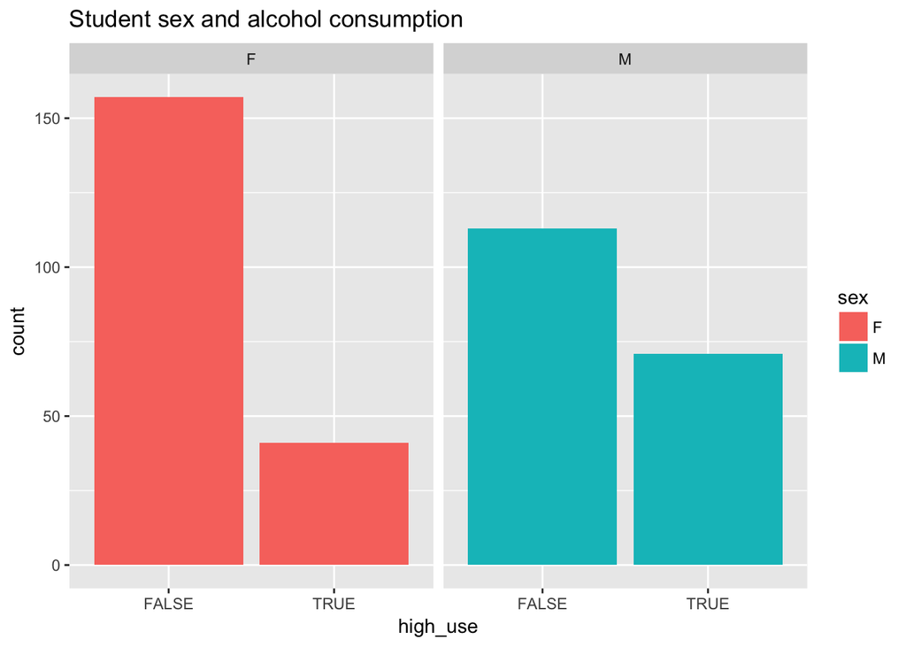

```r
#  a plot of high_use vs sex
g1 <- ggplot(data = alc, aes(x = high_use, fill = sex))
g1 + geom_bar() + facet_wrap("sex") + ggtitle("Student sex and alcohol consumption")
```

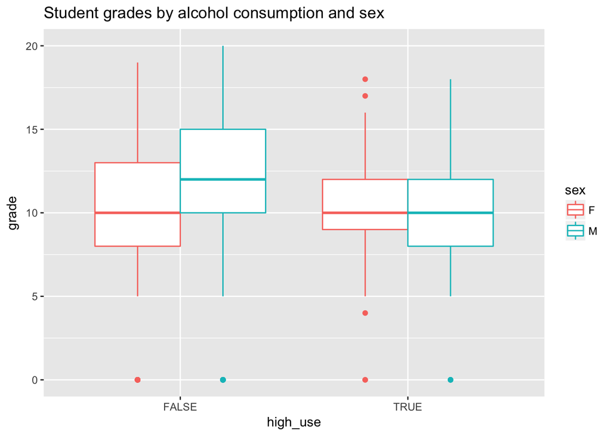

```r
# a plot of high use vs grades

g2 <- ggplot(alc, aes(x = high_use, y = G3, col = sex))
g2 + geom_boxplot() + ylab("grade") + ggtitle("Student grades by alcohol consumption and sex")
```

2. Grades: Alcohal consumption effects on the grades of only male students, we can observe this based on the box plot where grades of female students were uneffected and grades of male students are slightly going down with higher consumption of alcohal. My personal hypothesis is partially right in this case.

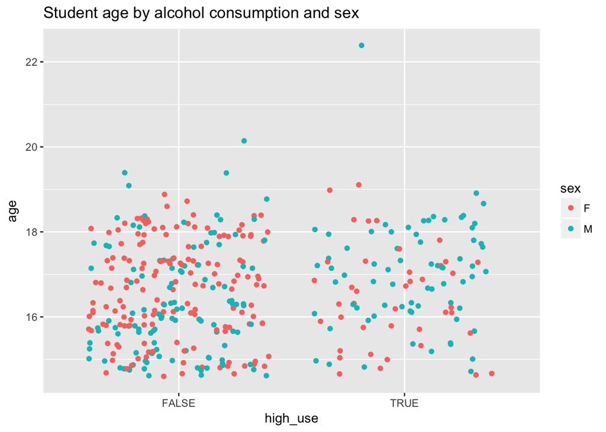

```r
# a plot between high use and age
g3 <- ggplot(data=alc, aes(x = high_use, y = age, col = sex))
g3 + geom_jitter()  + ggtitle("Student age by alcohol consumption and sex")
```

3. Age: We can see that alcohal use is random by age. It seems that age does not have direct effect on the alcohal consumption, as all the students scattered randomly or in other words irrespective of their age.

```r
# summary table
alc %>% group_by(high_use) %>% summarise(count = n(), mean_absences=mean(absences))
```

```
## # A tibble: 2 × 3
##   high_use count mean_absences
##      <lgl> <int>         <dbl>
## 1    FALSE   270      4.225926
## 2     TRUE   112      7.955357
```

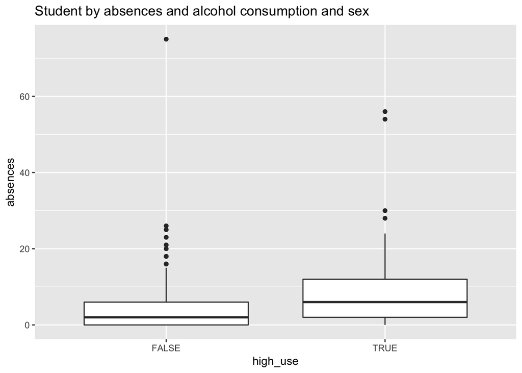

```r
# box plot high use and absences
g4 <- ggplot(alc, aes(x = high_use, y = absences))
g4 + geom_boxplot() + ggtitle("Student by absences and alcohol consumption and sex")
```

4. Absences: From the table, we can see that students those were away from school had higher consumption of alcohal. Similarly, box plot shows that higher the absence leads to more consumption of alcohal.

# Logistic regression and odds ratios

```r
# find the model with glm()
m <- glm(high_use ~  G3 + age + absences + sex, data = alc, family = "binomial")
# print out a summary of the model
summary(m)
```

```
##
## Call:
## glm(formula = high_use ~ G3 + age + absences + sex, family = "binomial",
##     data = alc)
##
## Deviance Residuals:
##     Min       1Q   Median       3Q      Max
## -2.7618  -0.8304  -0.6250   1.0653   2.0928
##
## Coefficients:
##             Estimate Std. Error z value Pr(>|z|)
## (Intercept) -3.74537    1.80436  -2.076   0.0379 *
## G3          -0.02780    0.02635  -1.055   0.2913
## age          0.13200    0.10385   1.271   0.2037
## absences     0.07215    0.01827   3.949 7.84e-05 ***
## sexM         1.03504    0.24496   4.225 2.38e-05 ***
## ---
## Signif. codes:  0 '***' 0.001 '**' 0.01 '*' 0.05 '.' 0.1 ' ' 1
##
## (Dispersion parameter for binomial family taken to be 1)
##
##     Null deviance: 462.21  on 381  degrees of freedom
## Residual deviance: 422.32  on 377  degrees of freedom
## AIC: 432.32
##
## Number of Fisher Scoring iterations: 4
```

```r
# print out the coefficients of the model
coef(m)
```

```
## (Intercept)          G3         age    absences        sexM
## -3.74537009 -0.02780439  0.13199888  0.07214611  1.03504370
```

```r
# compute odds ratios (OR)
OR <- coef(m) %>% exp
OR
```

```
## (Intercept)          G3         age    absences        sexM
##  0.02362688  0.97257860  1.14110704  1.07481238  2.81522924
```

```r
# compute confidence intervals (CI)
CI<- confint(m) %>% exp
CI
```

```
##                    2.5 %    97.5 %
## (Intercept) 0.0006530008 0.7858854
## G3          0.9237462161 1.0245877
## age         0.9317352660 1.4014357
## absences    1.0392052325 1.1160572
## sexM        1.7531743240 4.5888477
```

```r
# print out the odds ratios with their confidence intervals
cbind(OR, CI)
```

```
##                     OR        2.5 %    97.5 %
## (Intercept) 0.02362688 0.0006530008 0.7858854
## G3          0.97257860 0.9237462161 1.0245877
## age         1.14110704 0.9317352660 1.4014357
## absences    1.07481238 1.0392052325 1.1160572
## sexM        2.81522924 1.7531743240 4.5888477
```

Out of 4 varialbles only sex and absences have significant effect with p-value < 0.01 on the alcohal consumption, however grades and age does not have significant effet. Grades has negative coefficient and age, absence and sex haev positive coefficient. Null deviance is 462.21 on 381 degrees of freedom which suggest that there is some overdispersion in the model. Odds ratio for absences is 1.07 with (1.03 to 1.11) confidence interval of 95%, which means that there is 1.03 higher risk to have high alcohol consumption when the number of absences are higher. There is 2.8 higher risk for males to have high alcohol consumption than females with (1.75 to 4.5) confidence interval of 95%. On the ohter hand age has odds ratio almost equal (1.14) to absences but the confidence interval (2.5%) is only 0.9, suggesting age doest not have impact on the drinking. In summary, for a male, the odds of being alcohal consumption is 2.8 times larger than the odds for a female alcohal consumption. Based on this study, perhaps alcohal cessation programs should be targeted toward men.

# Predictive power, training error and cross-validation

Based on my results I am selecting only sex and absence as they had a statistical relationship with high/low alcohol consumption.

```r
m1 <- glm(high_use ~  absences + sex, data = alc, family = "binomial")
summary(m1)
```

```
##
## Call:
## glm(formula = high_use ~ absences + sex, family = "binomial",
##     data = alc)
##
## Deviance Residuals:
##     Min       1Q   Median       3Q      Max
## -2.7368  -0.8501  -0.5838   1.0919   1.9899
##
## Coefficients:
##             Estimate Std. Error z value Pr(>|z|)
## (Intercept) -1.83117    0.21956  -8.340  < 2e-16 ***
## absences     0.07403    0.01811   4.089 4.34e-05 ***
## sexM         0.99923    0.24179   4.133 3.59e-05 ***
## ---
## Signif. codes:  0 '***' 0.001 '**' 0.01 '*' 0.05 '.' 0.1 ' ' 1
##
## (Dispersion parameter for binomial family taken to be 1)
##
##     Null deviance: 462.21  on 381  degrees of freedom
## Residual deviance: 425.79  on 379  degrees of freedom
## AIC: 431.79
##
## Number of Fisher Scoring iterations: 4
```

```r
# predict() the probability of high_use
probabilities <- predict(m1, type = "response")

# add the predicted probabilities to 'alc'
alc <- mutate(alc, probability = probabilities)

# use the probabilities to make a prediction of high_use
alc <- mutate(alc, prediction = probability > 0.5)

# tabulate the target variable versus the predictions
table(high_use = alc$high_use, prediction = alc$prediction)
```

```
##         prediction
## high_use FALSE TRUE
##    FALSE   263    7
##    TRUE     89   23
```

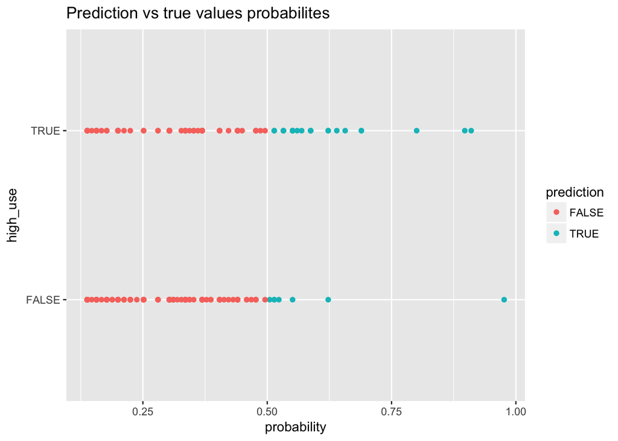

```r
# access dplyr and ggplot2
library(dplyr); library(ggplot2)

# initialize a plot of 'high_use' versus 'probability' in 'alc'
g <- ggplot(alc, aes(x = probability, y = high_use, col= prediction))
g + geom_point()+ggtitle("Prediction vs true values probabilites")
```

```r
# tabulate the target variable versus the predictions
table(high_use = alc$high_use, prediction = alc$prediction)
```

```
##         prediction
## high_use FALSE TRUE
##    FALSE   263    7
##    TRUE     89   23
```

```r
table(high_use = alc$high_use, prediction = alc$prediction) %>% prop.table() %>% addmargins()
```

```
##         prediction
## high_use      FALSE       TRUE        Sum
##    FALSE 0.68848168 0.01832461 0.70680628
##    TRUE  0.23298429 0.06020942 0.29319372
##    Sum   0.92146597 0.07853403 1.00000000
```

```r
# define a loss function (mean prediction error)
loss_func <- function(class, prob) {
  n_wrong <- abs(class - prob) > 0.5
  mean(n_wrong)
}

# call loss_func to compute the average number of wrong predictions in the (training) data
loss_func(class = alc$high_use, prob = alc$probability)
```

```
## [1] 0.2513089
```

There were 0.68 probability for both predicted and observed to be false and 0.06 probability for both predicted and observed to be true. The probability to false positives were 0.018 and 0.23 probability for false negatives.

# Bonus

```r
loss_func(class = alc$high_use, prob = alc$probability)
```

```
## [1] 0.2513089
```

```r
K = nrow(alc)

# K-fold cross-validation
library(boot)
cv <- cv.glm(data = alc, cost = loss_func, glmfit = m1, K = 10)

# average number of wrong predictions in the cross validation
cv$delta[1]
```

```
## [1] 0.2565445
```

My model is also having simillar error rate whcih is 0.26 as compared to the model introduced in DataCamp (which had about 0.26 error).

# Super-Bonus

Here, I selected 10 variables and found that only 4 variables have significant impact.

```r
m2 <- glm(high_use ~  absences + sex + romantic + traveltime + age + studytime + failures + goout +  guardian  +  schoolsup , data = alc, family = "binomial")

summary(m2)
```

```
##
## Call:
## glm(formula = high_use ~ absences + sex + romantic + traveltime +
##     age + studytime + failures + goout + guardian + schoolsup,
##     family = "binomial", data = alc)
##
## Deviance Residuals:
##     Min       1Q   Median       3Q      Max
## -1.8926  -0.7436  -0.4728   0.6685   2.5289
##
## Coefficients:
##                Estimate Std. Error z value Pr(>|z|)
## (Intercept)    -3.72667    2.03951  -1.827 0.067665 .
## absences        0.06815    0.01752   3.889 0.000101 ***
## sexM            0.72664    0.27746   2.619 0.008821 **
## romanticyes    -0.29248    0.29082  -1.006 0.314545
## traveltime      0.36555    0.18804   1.944 0.051896 .
## age             0.01936    0.12093   0.160 0.872830
## studytime      -0.39851    0.17701  -2.251 0.024367 *
## failures        0.16451    0.18489   0.890 0.373584
## goout           0.73157    0.12444   5.879 4.13e-09 ***
## guardianmother -0.49755    0.30663  -1.623 0.104670
## guardianother   0.19297    0.67541   0.286 0.775100
## schoolsupyes   -0.23331    0.42098  -0.554 0.579446
## ---
## Signif. codes:  0 '***' 0.001 '**' 0.01 '*' 0.05 '.' 0.1 ' ' 1
##
## (Dispersion parameter for binomial family taken to be 1)
##
##     Null deviance: 462.21  on 381  degrees of freedom
## Residual deviance: 363.79  on 370  degrees of freedom
## AIC: 387.79
##
## Number of Fisher Scoring iterations: 4
```

```r
library(boot)
cv <- cv.glm(data = alc, cost = loss_func, glmfit = m2, K = 10)

# average number of wrong predictions in the cross validation
cv$delta[1]
```

```
## [1] 0.2277487
```

```r
m3 <- glm(high_use ~  absences + sex  + traveltime +  goout  , data = alc, family = "binomial")
summary(m3)
```

```
##
## Call:
## glm(formula = high_use ~ absences + sex + traveltime + goout,
##     family = "binomial", data = alc)
##
## Deviance Residuals:
##     Min       1Q   Median       3Q      Max
## -1.9447  -0.7612  -0.5120   0.7181   2.4436
##
## Coefficients:
##             Estimate Std. Error z value Pr(>|z|)
## (Intercept) -4.84873    0.55949  -8.666  < 2e-16 ***
## absences     0.06633    0.01721   3.854 0.000116 ***
## sexM         0.96794    0.25975   3.726 0.000194 ***
## traveltime   0.42940    0.18081   2.375 0.017557 *
## goout        0.74278    0.12153   6.112 9.83e-10 ***
## ---
## Signif. codes:  0 '***' 0.001 '**' 0.01 '*' 0.05 '.' 0.1 ' ' 1
##
## (Dispersion parameter for binomial family taken to be 1)
##
##     Null deviance: 462.21  on 381  degrees of freedom
## Residual deviance: 375.69  on 377  degrees of freedom
## AIC: 385.69
##
## Number of Fisher Scoring iterations: 4
```

```r
library(boot)
cv <- cv.glm(data = alc, cost = loss_func, glmfit = m3, K = 10)

# average number of wrong predictions in the cross validation
cv$delta[1]
```

```
## [1] 0.2068063
```